# In Class Exam

Nick Grammas

Question 1: a.) the grammar graphics in this code are data, geom, aestetic mapping, stat, and coordinate function

b.) The principle is visual tasks and decoding graphs. In the current graph the audience would have to decode the graph and in doing so could easily make mistakes due to its randomness. When we put these types of graphs in order it is much easier to decode them and interpret them leading to easier analysis.

c.) Zero is needed in bar plots because as humans we need a reference point to truely understand and interpret how long each bar really is. Without that zero base it becomes difficult to interpret correctly. Zero doesn’t need to be in point plots because we can understand the trends in points much better. If zero was a requirement it could also be used to exaggerate data and mislead audiences as well.

Question 2:

Question 3: I learned that with data ethics it is really important to include all data and look for different perspectives to make sure all data is included. For example, in the challenger data set no one thought it would be that cold but it was and ended in tragedy. We need to have that open mind and think of many different possibilities to ensure we present correct and accurate information.

Question 4:

a.)

```r
library(maps)
library(tidyverse)
library(here)
election_df <- read_csv(here("2020_county_pres.csv")) %>%
  group_by(state_name) %>%
  summarise(total_gop = sum(votes_gop),
            total_dem = sum(votes_dem)) %>%
  mutate(percent_gop = 100 * total_gop / (total_gop + total_dem)) %>%
  mutate(state_name = str_to_lower(state_name))
election_df
```

```
## # A tibble: 51 × 4
##    state_name           total_gop total_dem percent_gop
##    <chr>                    <dbl>     <dbl>       <dbl>
##  1 alabama                1441168    849648       62.9
##  2 alaska                  189892    153405       55.3
##  3 arizona                1661686   1672143       49.8
##  4 arkansas                760647    423932       64.2
##  5 california             6005961  11109764       35.1
##  6 colorado               1364607   1804352       43.1
##  7 connecticut             715291   1080680       39.8
##  8 delaware                200603    296268       40.4
##  9 district of columbia     18586    317323        5.53
## 10 florida                5668731   5297045       51.7
## # … with 41 more rows
```

```r
state_df <- ggplot2::map_data("state")

library(lubridate)
state_full <- left_join(state_df, election_df, by = c("region" = "state_name"))
state_df
```

[output not shown]

[output cut: 15523 more lines]

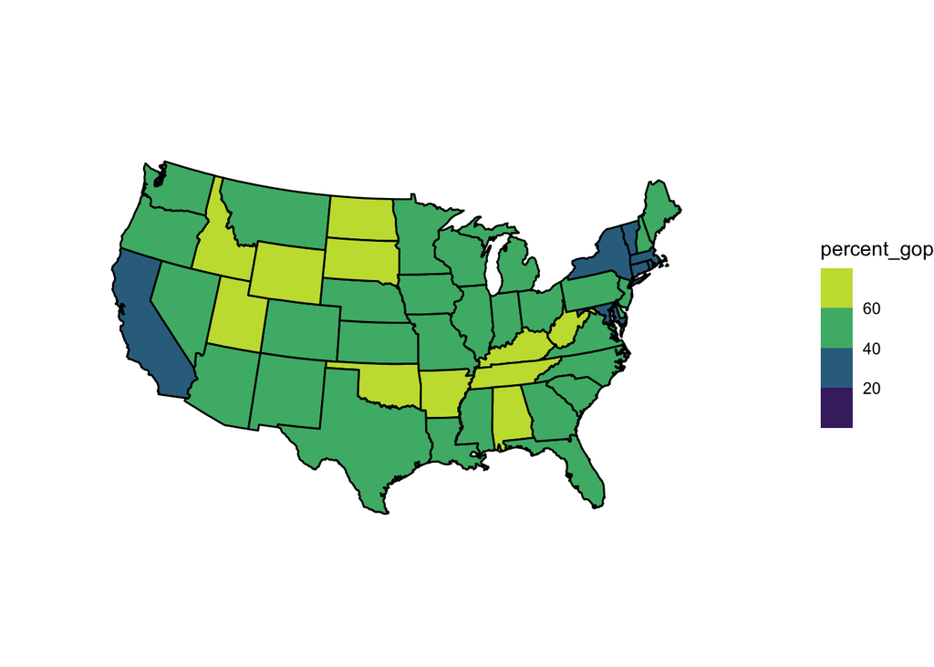

```r
ggplot(data = state_full, aes(x = long, y = lat, group = group)) +
  geom_polygon(colour = "black", aes(fill = percent_gop)) +
  coord_map(projection = "albers", lat0 = 39, lat1 = 45) +
  theme_void() +
  scale_fill_viridis_b()
```

b.) R needs much more than 50 rows to construct the US map because it creates the map based on latitude and longitude points of each state. Because of the many edges and corners there needs to be many points in order to do this.

Question 5:

```r
alcohol_df <- read_csv("data/alcohol.csv")
alcohol_df
```

```
## # A tibble: 193 × 5
##    country      beer_servings spirit_servings wine_servings total_litres_of_pur…
##    <chr>                <dbl>           <dbl>         <dbl>                <dbl>
##  1 Afghanistan              0               0             0                  0
##  2 Albania                 89             132            54                  4.9
##  3 Algeria                 25               0            14                  0.7
##  4 Andorra                245             138           312                 12.4
##  5 Angola                 217              57            45                  5.9
##  6 Antigua & B…           102             128            45                  4.9
##  7 Argentina              193              25           221                  8.3
##  8 Armenia                 21             179            11                  3.8
##  9 Australia              261              72           212                 10.4
## 10 Austria                279              75           191                  9.7
## # … with 183 more rows
```

Question 6:

Question 7:

```r
library(tidyverse)
library(here)
wta_df <- read_csv("data/wta_matches_2019.csv")
wta_long <- wta_df %>% pivot_longer(c(winner_name, loser_name),
                                    names_to = "won_or_lost",
                                    values_to = "player") %>%
  select(won_or_lost, player, everything(), w_ace, l_ace) %>%
  group_by(player, tourney_name) %>%
  summarise(nw_ace = sum(w_ace),
            nl_ace = sum(l_ace)) %>%
  mutate(avg_w_ace = nw_ace/nl_ace) %>%
  filter(avg_w_ace != "Inf",
         avg_w_ace != "NaN") %>%
  group_by(player, avg_w_ace) %>%
  summarise(mean_w_ace = mean(avg_w_ace)) %>%
  arrange(desc(mean_w_ace)) %>%
  filter(player == "Kristyna Pliskova" |
           player == "Qiang Wang" |
         player == "Jennifer Brady") %>%
  slice(1:3)
wta_long
```

```
## # A tibble: 9 × 3
## # Groups:   player [3]
##   player            avg_w_ace mean_w_ace
##   <chr>                 <dbl>      <dbl>
## 1 Jennifer Brady         2.83       2.83
## 2 Jennifer Brady         2.2        2.2
## 3 Jennifer Brady         2          2
## 4 Kristyna Pliskova      5.67       5.67
## 5 Kristyna Pliskova      3.88       3.88
## 6 Kristyna Pliskova      3          3
## 7 Qiang Wang             6          6
## 8 Qiang Wang             4          4
## 9 Qiang Wang             3.5        3.5
```

```r
wta_df
```

```
## # A tibble: 3,114 × 49
##    tourney_id tourney_name      surface draw_size tourney_level tourney_date
##    <chr>      <chr>             <chr>       <dbl> <chr>                <dbl>
##  1 2019-1103  Indian Wells 125K Hard           64 C                 20190225
##  2 2019-1103  Indian Wells 125K Hard           64 C                 20190225
##  3 2019-1103  Indian Wells 125K Hard           64 C                 20190225
##  4 2019-1103  Indian Wells 125K Hard           64 C                 20190225
##  5 2019-1103  Indian Wells 125K Hard           64 C                 20190225
##  6 2019-1103  Indian Wells 125K Hard           64 C                 20190225
##  7 2019-1103  Indian Wells 125K Hard           64 C                 20190225
##  8 2019-1103  Indian Wells 125K Hard           64 C                 20190225
##  9 2019-1103  Indian Wells 125K Hard           64 C                 20190225
## 10 2019-1103  Indian Wells 125K Hard           64 C                 20190225
## # … with 3,104 more rows, and 43 more variables: match_num <dbl>,
## #   winner_id <dbl>, winner_seed <chr>, winner_entry <chr>, winner_name <chr>,
## #   winner_hand <chr>, winner_ht <dbl>, winner_ioc <chr>, winner_age <dbl>,
## #   loser_id <dbl>, loser_seed <chr>, loser_entry <chr>, loser_name <chr>,
## #   loser_hand <chr>, loser_ht <dbl>, loser_ioc <chr>, loser_age <dbl>,
## #   score <chr>, best_of <dbl>, round <chr>, minutes <dbl>, w_ace <dbl>,
## #   w_df <dbl>, w_svpt <dbl>, w_1stIn <dbl>, w_1stWon <dbl>, w_2ndWon <dbl>, …
```

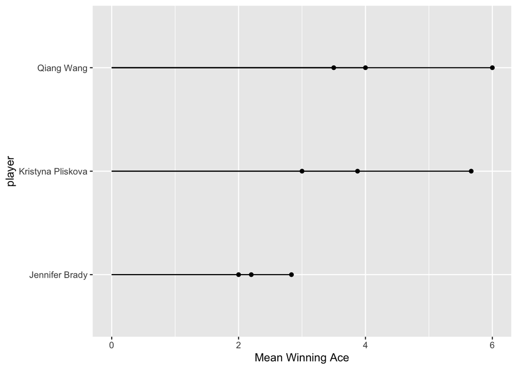

```r
ggplot(data = wta_long, aes(x = player, y = mean_w_ace)) +
  geom_point() +
  geom_segment(aes(x = player, xend = player, y = 0, yend = mean_w_ace)) +
  coord_flip() +
  labs(y = "Mean Winning Ace")
```

Question 8:

a.) This plot is not great for showing the top servers in 2019 because it does not show us the variability in this graph. For example, there could have been one player that was on fire with her serve but ended up getting injured. This plot doesn’t really show us that and as a result we don’t know much about the actual tennis season because of it. Additionally, this data set has many different levels of tournament play so there could have been one athlete dominating opponents on the lowest level.

```r
library(tibble)
set.seed(03092022)
toy_df <- tibble(group = c("a", "a", "a", "b", "b", "b", "c", "c",
                           "c", "c", "d", "d"),
       response = rnorm(12, 4, 3))

toy_df_mean <- toy_df %>% group_by(group) %>%
    summarise(meanresponse = mean(response),
            sdresponse = sd(response),
            nresponse = n()) %>%
  mutate(l_se = meanresponse - sdresponse / sqrt(nresponse),
         u_se = meanresponse + sdresponse / sqrt(nresponse))
toy_df_mean
```

```
## # A tibble: 4 × 6
##   group meanresponse sdresponse nresponse  l_se  u_se
##   <chr>        <dbl>      <dbl>     <int> <dbl> <dbl>
## 1 a             5.49       2.55         3  4.02  6.96
## 2 b             6.27       1.31         3  5.51  7.02
## 3 c             6.32       5.64         4  3.49  9.14
## 4 d             6.31       2.88         2  4.28  8.34
```

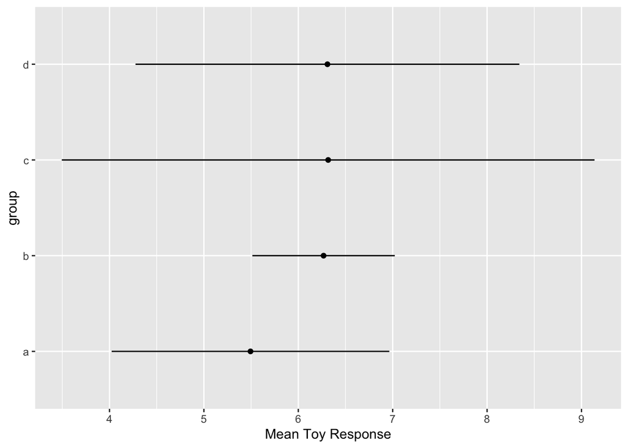

```r
ggplot(data = toy_df_mean, aes(x = group, y = meanresponse)) +
  geom_point() +
  geom_segment(aes(x = group, xend = group, y = l_se, yend = u_se)) +
  coord_flip() +
  labs(y = "Mean Toy Response")
```